# Harsh Singal, OBAIS, University of Cincinnati (June 15, 2020)

# Lab-4

The objective of this case is to get you understand logistic regression (binary classification) and some important ideas such as cross validation, ROC curve, cut-off probability.

```python
import pandas as pd
import numpy as np
import sklearn
import matplotlib.pyplot as plt
import seaborn as sns
import warnings
warnings.filterwarnings("ignore")
```

# 1 Input and sample data

We will use a Credit Card Default Data for this lab and illustration. The details of the data can be found at http://archive.ics.uci.edu/ml/datasets/default+of+credit+card+clients. Think about what kind of factors could affect people to fail to pay their credit balance.

First load the credit scoring data. It is easy to load comma-separated values (CSV).

```python
credit_data = pd.read_csv("credit_default.csv")
credit_data.head()
```

|  | LIMIT_BAL | SEX | EDUCATION | MARRIAGE | AGE | PAY_0 | PAY_2 | PAY_3 | PAY_4 | PAY_5 | ... | BILL_AMT4 | BILL_AMT5 | BILL_AMT6 | PAY_AMT1 | PAY_AMT2 | PAY_AMT3 | PAY_AMT4 | PAY_AMT5 | PAY_AMT6 | default.payment.next.month |
| --- | --- | --- | --- | --- | --- | --- | --- | --- | --- | --- | --- | --- | --- | --- | --- | --- | --- | --- | --- | --- | --- |
| 0 | 290000 | 2 | 2 | 2 | 26 | 0 | 0 | 0 | 0 | -1 | ... | 100000 | 3015 | 23473 | 3000 | 80000 | 3000 | 3015 | 23473 | 1148 | 0 |
| 1 | 20000 | 1 | 2 | 2 | 51 | -1 | -1 | -2 | -1 | -1 | ... | 780 | 0 | 0 | 0 | 0 | 2280 | 0 | 0 | 0 | 0 |
| 2 | 280000 | 1 | 1 | 2 | 29 | -2 | -2 | -2 | -2 | -2 | ... | 2510 | 591 | 14994 | 5123 | 8467 | 2510 | 591 | 14994 | 5000 | 0 |
| 3 | 280000 | 2 | 1 | 2 | 47 | 0 | 0 | 0 | 0 | 0 | ... | 184270 | 130954 | 92215 | 11268 | 8196 | 6281 | 4403 | 3532 | 3510 | 0 |
| 4 | 20000 | 1 | 2 | 2 | 24 | 0 | 0 | 0 | 0 | 0 | ... | 19396 | 11643 | 11578 | 1400 | 1380 | 1181 | 1000 | 500 | 500 | 0 |

5 rows × 24 columns

```python
credit_data.columns
```

```
Index(['LIMIT_BAL', 'SEX', 'EDUCATION', 'MARRIAGE', 'AGE', 'PAY_0', 'PAY_2',
       'PAY_3', 'PAY_4', 'PAY_5', 'PAY_6', 'BILL_AMT1', 'BILL_AMT2',
       'BILL_AMT3', 'BILL_AMT4', 'BILL_AMT5', 'BILL_AMT6', 'PAY_AMT1',
       'PAY_AMT2', 'PAY_AMT3', 'PAY_AMT4', 'PAY_AMT5', 'PAY_AMT6',
       'default.payment.next.month'],
      dtype='object')
```

The name of response variable is too long! I want to make it shorter by renaming. Recall the rename() function.

```python
credit_data.rename(columns={'default.payment.next.month' : 'DEFAULT'}, inplace = True)
```

Let’s look at how many people were actually default in this sample.

```python
credit_data['DEFAULT'].mean()
```

```
0.21933333333333332
```

How about the variable type and summary statistics?

```python
credit_data.dtypes
```

```
LIMIT_BAL    int64
SEX          int64
EDUCATION    int64
MARRIAGE     int64
AGE          int64
PAY_0        int64
PAY_2        int64
PAY_3        int64
PAY_4        int64
PAY_5        int64
PAY_6        int64
BILL_AMT1    int64
BILL_AMT2    int64
BILL_AMT3    int64
BILL_AMT4    int64
BILL_AMT5    int64
BILL_AMT6    int64
PAY_AMT1     int64
PAY_AMT2     int64
PAY_AMT3     int64
PAY_AMT4     int64
PAY_AMT5     int64
PAY_AMT6     int64
DEFAULT      int64
dtype: object
```

```python
credit_data.describe()
```

|  | LIMIT_BAL | SEX | EDUCATION | MARRIAGE | AGE | PAY_0 | PAY_2 | PAY_3 | PAY_4 | PAY_5 | ... | BILL_AMT4 | BILL_AMT5 | BILL_AMT6 | PAY_AMT1 | PAY_AMT2 | PAY_AMT3 | PAY_AMT4 | PAY_AMT5 | PAY_AMT6 | DEFAULT |
| --- | --- | --- | --- | --- | --- | --- | --- | --- | --- | --- | --- | --- | --- | --- | --- | --- | --- | --- | --- | --- | --- |
| count | 12000.000000 | 12000.000000 | 12000.000000 | 12000.000000 | 12000.000000 | 12000.000000 | 12000.000000 | 12000.000000 | 12000.000000 | 12000.000000 | ... | 12000.000000 | 12000.000000 | 12000.000000 | 12000.000000 | 1.200000e+04 | 12000.000000 | 12000.000000 | 12000.000000 | 12000.000000 | 12000.000000 |
| mean | 167501.333333 | 1.602917 | 1.844333 | 1.551500 | 35.499667 | -0.015750 | -0.128000 | -0.166667 | -0.225583 | -0.267833 | ... | 43101.557667 | 40314.199833 | 38821.438833 | 5766.057333 | 6.250060e+03 | 5194.665167 | 4878.389417 | 4868.498167 | 5432.712083 | 0.219333 |
| std | 130334.212375 | 0.489314 | 0.745306 | 0.520772 | 9.226480 | 1.128616 | 1.192645 | 1.187226 | 1.152522 | 1.123478 | ... | 64429.407522 | 61042.768474 | 59611.508898 | 15989.660757 | 2.362472e+04 | 17820.014810 | 15569.863239 | 15279.952500 | 19044.129946 | 0.413812 |
| min | 10000.000000 | 1.000000 | 1.000000 | 1.000000 | 21.000000 | -2.000000 | -2.000000 | -2.000000 | -2.000000 | -2.000000 | ... | -81334.000000 | -81334.000000 | -339603.000000 | 0.000000 | 0.000000e+00 | 0.000000 | 0.000000 | 0.000000 | 0.000000 | 0.000000 |
| 25% | 50000.000000 | 1.000000 | 1.000000 | 1.000000 | 28.000000 | -1.000000 | -1.000000 | -1.000000 | -1.000000 | -1.000000 | ... | 2411.000000 | 1863.250000 | 1308.750000 | 1000.000000 | 9.447500e+02 | 400.000000 | 300.000000 | 300.000000 | 142.750000 | 0.000000 |
| 50% | 140000.000000 | 2.000000 | 2.000000 | 2.000000 | 34.000000 | 0.000000 | 0.000000 | 0.000000 | 0.000000 | 0.000000 | ... | 19077.500000 | 18244.000000 | 17130.000000 | 2128.000000 | 2.013000e+03 | 1827.000000 | 1500.000000 | 1518.000000 | 1500.000000 | 0.000000 |
| 75% | 240000.000000 | 2.000000 | 2.000000 | 2.000000 | 41.000000 | 0.000000 | 0.000000 | 0.000000 | 0.000000 | 0.000000 | ... | 53117.250000 | 49927.250000 | 48938.000000 | 5006.000000 | 5.000000e+03 | 4505.000000 | 4078.500000 | 4120.750000 | 4061.750000 | 0.000000 |
| max | 1000000.000000 | 2.000000 | 4.000000 | 3.000000 | 79.000000 | 8.000000 | 7.000000 | 7.000000 | 7.000000 | 7.000000 | ... | 891586.000000 | 927171.000000 | 961664.000000 | 493358.000000 | 1.227082e+06 | 896040.000000 | 432130.000000 | 426529.000000 | 528666.000000 | 1.000000 |

8 rows × 24 columns

# 2 Two-way contingency table and Chi-square test

Two-way contingency table is a very useful tool for exploring the relationship between categorical variables. It is essentially the simplest pivot-table (see example below). Often time, after you create a two-way contingency table, Chi-square test is used to test if X affect Y. The null hypothesis is: X and Y are independent (e.g., MARRIAGE has nothing to do with likelihood of default).

Here is a very good tutorial for Chi-square test https://www.youtube.com/watch?v=WXPBoFDqNVk.

```python
pd.crosstab(credit_data['EDUCATION'], credit_data['DEFAULT'], margins = False)
```

| DEFAULT EDUCATION | 0 | 1 |
| --- | --- | --- |
| 1 | 3399 | 829 |
| 2 | 4298 | 1298 |
| 3 | 1501 | 491 |
| 4 | 170 | 14 |

```python
from scipy import stats

class ChiSquare:
    def __init__(self, dataframe):
        self.df = dataframe
        self.p = None #P-Value
        self.chi2 = None #Chi Test Statistic
        self.dof = None

        self.dfObserved = None
        self.dfExpected = None

    def _print_chisquare_result(self, colX, alpha):
        result = ""
        if self.p<alpha:
            result="{0} is IMPORTANT for Prediction".format(colX)
        else:
            result="{0} is NOT an important predictor. (Discard {0} from model)".format(colX)
        print(result)

    def TestIndependence(self,colX,colY, alpha=0.05):
        X = self.df[colX].astype(str)
        Y = self.df[colY].astype(str)

        self.dfObserved = pd.crosstab(Y,X)
        chi2, p, dof, expected = stats.chi2_contingency(self.dfObserved.values)
        self.p = p
        self.chi2 = chi2
        self.dof = dof

        self.dfExpected = pd.DataFrame(expected, columns=self.dfObserved.columns, index = self.dfObserved.index)

        self._print_chisquare_result(colX,alpha)
```

```python
cT = ChiSquare(credit_data)
cT.TestIndependence(colX='EDUCATION', colY='DEFAULT' )
```

```
EDUCATION is IMPORTANT for Prediction
```

What we saw from above test result is that EDUCATION is important variable and hence has p-value < 0.05. What is your conclusion?

We omit other EDA, but you shouldn’t whenever you are doing data analysis.

# 3 Logistic Regression

Randomly split the data to training (80%) and testing (20%) datasets:

```python
from sklearn.model_selection import train_test_split
from random import sample
```

```python
#for statmodels smf function (explained in Model Building section)
num = list(range(len(credit_data)))
ran = sample(num, int(len(num)*0.8))
rem = [i for i in num if i not in ran]

credit_train = credit_data.iloc[ran, :]
credit_test = credit_data.iloc[rem, :]

#for sklearn LogisticRegression function

X_train = credit_train.iloc[:,:-1]
y_train = credit_train.iloc[:,-1:]

X_test = credit_test.iloc[:,:-1]
y_test = credit_test.iloc[:,-1:]
```

## 3.1 Train a logistic regression model with all X variables

```python
import statsmodels.api as sm
import statsmodels.formula.api as smf


formula = 'DEFAULT ~ LIMIT_BAL + SEX + EDUCATION + MARRIAGE + AGE + PAY_0 + PAY_2 + PAY_3 + \
                      PAY_4 + PAY_5 + PAY_6 + BILL_AMT1 + BILL_AMT2 + BILL_AMT3 + BILL_AMT4 + BILL_AMT5 + \
                      BILL_AMT6 + PAY_AMT1 + PAY_AMT2 + PAY_AMT3 + PAY_AMT4 + PAY_AMT5 + PAY_AMT6'

model1 = smf.glm(formula = formula, data = credit_train, family=sm.families.Binomial(link=sm.families.links.logit())).fit()
model1.summary()
```

Generalized Linear Model Regression Results

| Dep. Variable: | DEFAULT | No. Observations: | 9600 |
| --- | --- | --- | --- |
| Model: | GLM | Df Residuals: | 9576 |
| Model Family: | Binomial | Df Model: | 23 |
| Link Function: | logit | Scale: | 1.0000 |
| Method: | IRLS | Log-Likelihood: | -4386.7 |
| Date: | Sun, 14 Jun 2020 | Deviance: | 8773.3 |
| Time: | 23:57:46 | Pearson chi2: | 1.20e+04 |
| No. Iterations: | 6 |  |  |
| Covariance Type: | nonrobust |  |  |

|  | coef | std err | z | P>\|z\| | [0.025 | 0.975] |
| --- | --- | --- | --- | --- | --- | --- |
| Intercept | -0.6183 | 0.212 | -2.915 | 0.004 | -1.034 | -0.203 |
| LIMIT_BAL | -9.973e-07 | 2.86e-07 | -3.491 | 0.000 | -1.56e-06 | -4.37e-07 |
| SEX | -0.1253 | 0.055 | -2.290 | 0.022 | -0.233 | -0.018 |
| EDUCATION | -0.1882 | 0.040 | -4.719 | 0.000 | -0.266 | -0.110 |
| MARRIAGE | -0.1449 | 0.057 | -2.547 | 0.011 | -0.256 | -0.033 |
| AGE | 0.0099 | 0.003 | 3.114 | 0.002 | 0.004 | 0.016 |
| PAY_0 | 0.6160 | 0.032 | 19.381 | 0.000 | 0.554 | 0.678 |
| PAY_2 | 0.0455 | 0.037 | 1.245 | 0.213 | -0.026 | 0.117 |
| PAY_3 | 0.0955 | 0.040 | 2.361 | 0.018 | 0.016 | 0.175 |
| PAY_4 | 0.0683 | 0.045 | 1.517 | 0.129 | -0.020 | 0.157 |
| PAY_5 | 0.0201 | 0.048 | 0.416 | 0.677 | -0.074 | 0.115 |
| PAY_6 | 0.0013 | 0.040 | 0.033 | 0.974 | -0.078 | 0.080 |
| BILL_AMT1 | -4.876e-06 | 1.9e-06 | -2.568 | 0.010 | -8.6e-06 | -1.15e-06 |
| BILL_AMT2 | 3.81e-06 | 2.43e-06 | 1.567 | 0.117 | -9.56e-07 | 8.58e-06 |
| BILL_AMT3 | -9.177e-07 | 2.29e-06 | -0.401 | 0.689 | -5.41e-06 | 3.57e-06 |
| BILL_AMT4 | -4.94e-06 | 2.68e-06 | -1.844 | 0.065 | -1.02e-05 | 3.12e-07 |
| BILL_AMT5 | 5.259e-06 | 3.07e-06 | 1.715 | 0.086 | -7.5e-07 | 1.13e-05 |
| BILL_AMT6 | 1.223e-06 | 2.28e-06 | 0.536 | 0.592 | -3.24e-06 | 5.69e-06 |
| PAY_AMT1 | -1.078e-05 | 3.5e-06 | -3.078 | 0.002 | -1.76e-05 | -3.92e-06 |
| PAY_AMT2 | -7.458e-06 | 3.51e-06 | -2.128 | 0.033 | -1.43e-05 | -5.88e-07 |
| PAY_AMT3 | -2.543e-06 | 3e-06 | -0.847 | 0.397 | -8.43e-06 | 3.34e-06 |
| PAY_AMT4 | -7.417e-06 | 3.21e-06 | -2.313 | 0.021 | -1.37e-05 | -1.13e-06 |
| PAY_AMT5 | -2.366e-07 | 2.97e-06 | -0.080 | 0.936 | -6.06e-06 | 5.58e-06 |
| PAY_AMT6 | -2.608e-06 | 2.12e-06 | -1.231 | 0.218 | -6.76e-06 | 1.54e-06 |

Like the linear regression model, both sklearn's LogisticRegression and statsmodels glm functions can used to build logistic regression model. We will use statsmodels function to get the overall variable summary and sklearn function to get the scoring parameters. In statsmodels, you may also specify the link function after the name of distribution, for example, link=sm.families.links.logit(). You can also specify link=sm.families.links.probit() to run probit regression. You may also use glm() to build many other generalized linear models.

## 3.2 Get some criteria of model fitting

You can simply extract some criteria of the model fitting, for example, Residual deviance (equivalent to SSE in linear regression model), AIC and BIC. Unlike linear regression models, there is no R^2 in logistic regression.

```python
model1.deviance
```

```
8773.339706917188
```

```python
model1.aic
```

```
8821.339706917186
```

## 3.3 Prediction

Similar to linear regression, we use predict() function for prediction.

To get prediction from a logistic regression model, there are several steps you need to understand. Refer to textbook/slides for detailed math.

1.The fitted model η^=b0+b1x1+b2x2+... gives you the estimated value before the inverse of link (logit in case of logistic regression). In logistic regression the η are called log odds ratio, which is log(P(y=1)/(1−P(y=1))). In Python you use the predict() and linear = True function to get a vector of all in-sample η (for each training obs).

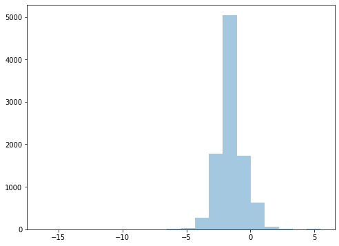

```python
pred = model1.predict(credit_train, linear = True)

plt.figure(figsize = (8,6))
sns.distplot(pred, bins = 20, hist = True, kde = False)
plt.show()
```

2.For each η, in order to get the P(y=1), we can apply the inverse of the link function (logit here) to η. The equation is P(y=1)=1/(1+exp(−η^)). In Python you use the predict() and linear = False function to get the predicted probability for each training ob.

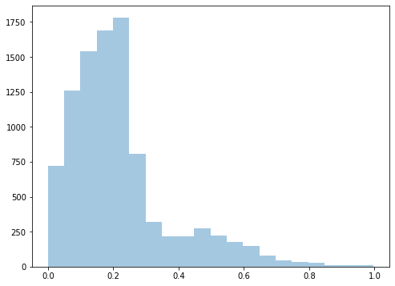

```python
pred = model1.predict(credit_train, linear = False)

plt.figure(figsize = (8,6))
sns.distplot(pred, bins = 20, hist = True, kde = False)
plt.show()
```

3.Last but not least, you want a binary classification decision rule. The default rule is if the fitted P(y=1)>0.5 then y=1. The value 0.5 is called cut-off probability. You can choose the cut-off probability based on mis-classification rate, cost function, etc. In this case, the cost function can indicate the trade off between the risk of giving loan to someone who cannot pay (predict 0, truth 1), and risk of rejecting someone who qualifys (predict 1, truth 0).

These tables illustrate the impact of choosing different cut-off probability. Choosing a large cut-off probability will result in few cases being predicted as 1, and chossing a small cut-off probability will result in many cases being predicted as 1.

```python
(model1.predict(credit_train, linear = False) > 0.5).value_counts()
```

```
False    8846
True      754
dtype: int64
```

```python
(model1.predict(credit_train, linear = False) > 0.2).value_counts()
```

```
False    5248
True     4352
dtype: int64
```

```python
(model1.predict(credit_train, linear = False) > 0.0001).value_counts()
```

```
True     9598
False       2
dtype: int64
```

### 3.3.1 In-sample prediction (less important)

```python
pred = model1.predict(credit_train, linear = False)
```

#### 3.3.1.1 ROC Curve

In order to show give an overall measure of goodness of classification, using the Receiver Operating Characteristic (ROC) curve is one way. Rather than use an overall misclassification rate, it employs two measures – true positive fraction (TPF) and false positive fraction (FPF).

[figure not shown]

```python
from sklearn import metrics

fpr, tpr, threshold = metrics.roc_curve(y_train, pred)
roc_auc = metrics.auc(fpr, tpr)
roc_auc
```

```
0.7313799509342491
```

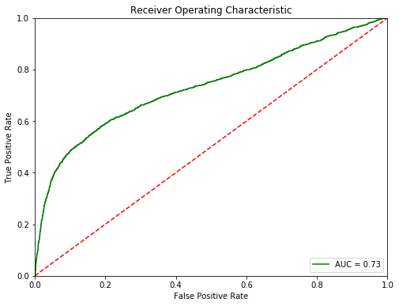

```python
plt.figure(figsize = (8,6))
plt.title('Receiver Operating Characteristic');
plt.plot(fpr, tpr, 'b', color = 'green',label = 'AUC = %0.2f' % roc_auc);
plt.legend(loc = 'lower right')
plt.plot([0, 1], [0, 1],'r--')
plt.xlim([0, 1])
plt.ylim([0, 1])
plt.ylabel('True Positive Rate')
plt.xlabel('False Positive Rate')
plt.show()
```

#### 3.3.1.2 Precision-Recall Curve

```python
from sklearn.metrics import precision_recall_curve
```

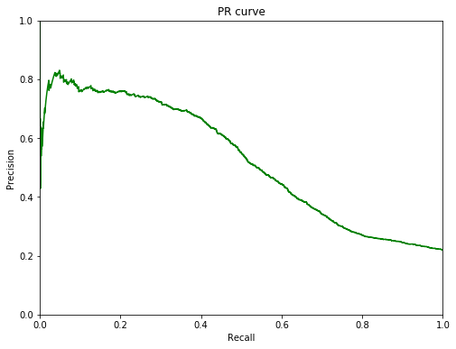

```python
pre, rec, thr = precision_recall_curve(y_train, pred)


plt.figure(figsize = (8,6))
plt.title('PR curve');
plt.plot(rec, pre, 'b', color = 'green')
plt.xlim([0, 1])
plt.ylim([0, 1])
plt.ylabel('Precision')
plt.xlabel('Recall')
plt.show()
```

### 3.3.2 Out-of-sample prediction (more important)

```python
test_pred = model1.predict(credit_test, linear = False)
```

#### 3.3.2.1 ROC Curve

```python
fpr, tpr, threshold = metrics.roc_curve(y_test, test_pred)
roc_auc = metrics.auc(fpr, tpr)
roc_auc
```

```
0.7084633734070617
```

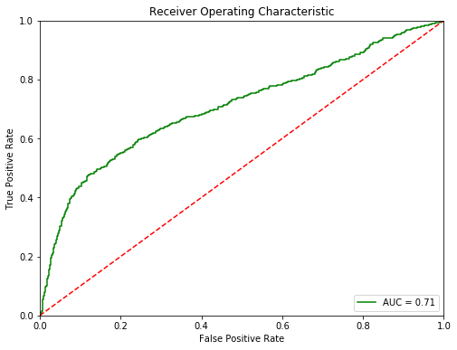

```python
plt.figure(figsize = (8,6))
plt.title('Receiver Operating Characteristic');
plt.plot(fpr, tpr, 'b', color = 'green',label = 'AUC = %0.2f' % roc_auc);
plt.legend(loc = 'lower right')
plt.plot([0, 1], [0, 1],'r--')
plt.xlim([0, 1])
plt.ylim([0, 1])
plt.ylabel('True Positive Rate')
plt.xlabel('False Positive Rate')
plt.show()
```

#### 3.3.2.2 Precision-Recall Curve

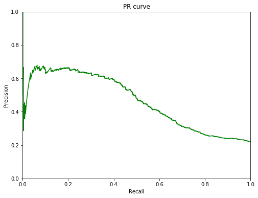

```python
pre, rec, thr = precision_recall_curve(y_test, test_pred)


plt.figure(figsize = (8,6))
plt.title('PR curve');
plt.plot(rec, pre, 'b', color = 'green')
plt.xlim([0, 1])
plt.ylim([0, 1])
plt.ylabel('Precision')
plt.xlabel('Recall')
plt.show()
```

## 3.4 Binary Classification

As we talked in the lecture, people may be more interested in the classification results. But we have to define a cut-off probability first.

These tables illustrate the impact of choosing different cut-off probability. Choosing a large cut-off probability will result in few cases being predicted as 1, and chossing a small cut-off probability will result in many cases being predicted as 1.

```python
((model1.predict(credit_train, linear = False) > 0.9)*1).value_counts()
```

```
0    9575
1      25
dtype: int64
```

```python
((model1.predict(credit_train, linear = False) > 0.5)*1).value_counts()
```

```
0    8846
1     754
dtype: int64
```

```python
((model1.predict(credit_train, linear = False) > 0.2)*1).value_counts()
```

```
0    5248
1    4352
dtype: int64
```

```python
((model1.predict(credit_train, linear = False) > 0.0001)*1).value_counts()
```

```
1    9598
0       2
dtype: int64
```

Therefore, determine the optimal cut-off probability is crucial. The simplest way to determine the cut-off is to use the proportion of “1” in the original data. We will intriduce a more appropriate way to determine the optimal p-cut.

### 3.4.1 Naive Choice of Cut-off probability

```python
pcut1 = credit_data['DEFAULT'].mean()
```

Based on this cut-off probability, we can obtain the binary prediction (predicted classification) and the confusion matrix

```python
pred = model1.predict(credit_train, linear = False)

# get binary prediction
pred_values = (pred > pcut1)*1


# get confusion matrix
data = pd.DataFrame({'Predicted': pred_values, 'True': y_train.DEFAULT})
confusion_matrix = pd.crosstab(data['True'], data['Predicted'], rownames=['True'], colnames=['Predicted'])
print(confusion_matrix)
```

```
Predicted     0     1
True
0          5270  2227
1           724  1379
```

It is easy to get different types of classification error rate, i.e., false positive rate (FPR), false negative rate (FNR), and overall misclassification rate (MR). Commonly, you can use overall MR as the cost (a criterion) to evaluate the model prediction.

## 3.4.2 Determine Optimal cut-off Probability using Grid Search Method

Recall the lecture, different p-cut results in different confusion matrix, hence different MR (or cost). You need to search all possible p-cut to find the one that provides minimum cost. The first step is to define a symmetric/asymmetric cost function (misclassification rate), as a function of cut-off. Think about what else is needed to calculate MR? The answer is observed Y and predicted probability.

```python
# define a cost function with input "obs" being observed response
# and "pi" being predicted probability, and "pcut" being the threshold.

def costfunc(obs, pred, pcut):
    weight1 = 5                               # define the weight for "true=1 but pred=0" (FN)
    weight0 = 1                               # define the weight for "true=0 but pred=1" (FP)
    c1 = (obs==1) & (pred < pcut)             # count for "true=1 but pred=0"   (FN)
    c0 = (obs==0) & (pred >= pcut)            # count for "true=0 but pred=1"   (FP)
    cost = (weight1*c1 + weight0*c0).mean()   # misclassification with weight
    return cost                               # you have to return to a value when you write Python functions
```

Next, define a sequence of probability (you need to search the optimal p-cut from this sequence)

```python
seq = np.arange(0.01, 1, 0.01)
```

Then, you need to calculate the cost (as you defined before) for each probability in the sequence seq.

```python
# write a loop for all p-cut to see which one provides the smallest cost
# first, need to define a 0 vector in order to save the value of cost from all pcut


pred = model1.predict(credit_train, linear = False)
obs = y_train.DEFAULT

cost = []

for i in range(len(seq)):
    cost.append(costfunc(obs = obs, pred = pred, pcut = seq[i]))
```

Last, draw a plot with cost against p.seq, and find the p-cut that gives you the minimum cost.

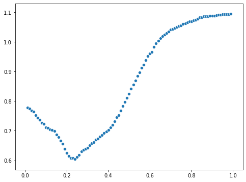

```python
plt.figure(figsize = (8,6))
sns.scatterplot(seq, cost)
plt.show()
```

```python
# find the optimal pcut
optimal_pcut = seq[cost.index(min(cost))]
optimal_pcut
```

```
0.24000000000000002
```

#### 3.4.2.1 Use the optimal cut-off probability

Now let calculate MR, FPR, FNR, and cost based on the optimal cut-off.

```python
# step 1. get binary classification
opt_pred = (pred > optimal_pcut)*1

# step 2. get confusion matrix, MR, FPR, FNR
data = pd.DataFrame({'Predicted': opt_pred, 'True': y_train.DEFAULT})
confusion_matrix = pd.crosstab(data['True'], data['Predicted'], rownames=['True'], colnames=['Predicted'])
print(confusion_matrix)
```

```
Predicted     0     1
True
0          5921  1576
1           845  1258
```

```python
MR =  (obs != opt_pred).mean()
FPR = ((obs==0) & (opt_pred==1)).sum()/(obs==0).sum()
FNR = ((obs==1) & (opt_pred==0)).sum()/(obs==1).sum()
cost = costfunc(obs = obs, pred = pred, pcut = optimal_pcut)
```

### 3.4.3 Out-of-sample Classification

Everything you have done about classification so far is for training sample. Now let’s get to testing sample. Keep in mind the principle, testing sample is only used for evaluating your model’s prediction accuracy! NO NEED TO CHOOSE CUT-OFF PROBABILITY in this stage.

#### 3.4.3.1 Exercise:

- Calculate MR, FPR, FNR based on the optimal cut-off you get from training sample with weights (5:1)
- Calculate asymetric cost based on the optimal cut-off you get from training sample with weights (5:1)
- Calculate above statistics based on the cut-off you get from training sample with symmetric weights (1:1)

## 3.5 Variable Selection

### 3.5.1 Variable Selection with Stepwise Approach

We can use the same procedures of variable selection, i.e. forward, backward, and stepwise, for linear regression models.

```python
#Forward Selection using AIC values

def forward_selection(data, target):

    initial_features = data.columns.tolist()
    best_features = []

    aic = sm.GLM(target, sm.add_constant(data[best_features]),
                 family=sm.families.Binomial(link=sm.families.links.logit())).fit().aic

    aic_values = [aic]

    while (len(initial_features) > 0):
        remaining_features = list(set(initial_features) - set(best_features))
        new_aic = pd.Series(index = remaining_features)

        for new_column in remaining_features:
            model = sm.GLM(target, sm.add_constant(data[best_features+[new_column]]),
                    family=sm.families.Binomial(link=sm.families.links.logit())).fit()
            new_aic[new_column] = model.aic
        min_aic = new_aic.min()

        if(min_aic < aic):
            aic = min_aic
            aic_values.append(aic)
            best_features.append(new_aic.idxmin())
        else:
            break

    final_AIC = sm.OLS(target, sm.add_constant(data[list(best_features)])).fit().aic

    return best_features, final_AIC
```

You can try model selection with BIC (usually results in a simpler model than AIC criterion)

```python
def forward_selection_bic(data, target):

    initial_features = data.columns.tolist()
    best_features = []

    bic = sm.GLM(target, sm.add_constant(data[best_features]),
                 family=sm.families.Binomial(link=sm.families.links.logit())).fit().bic

    bic_values = [bic]

    while (len(initial_features) > 0):
        remaining_features = list(set(initial_features) - set(best_features))
        new_aic = pd.Series(index = remaining_features)

        for new_column in remaining_features:
            model = sm.GLM(target, sm.add_constant(data[best_features+[new_column]]),
                    family=sm.families.Binomial(link=sm.families.links.logit())).fit()
            new_aic[new_column] = model.bic
        min_bic = new_bic.min()

        if(min_bic < bic):
            bic = min_bic
            bic_values.append(bic)
            best_features.append(new_aic.idxmin())
        else:
            break

    final_BIC = sm.OLS(target, sm.add_constant(data[list(best_features)])).fit().bic

    return best_features, final_BIC
```

Exercise: Try forward and stepwise selection procedures to see if they deliver the same best model.

#### 3.5.1.1 Exercise:

- Get ROC curve and AUC for both training and testing sample
- Using training sample, find the optimal cut-off by grid search method with asymmetric cost (weights ratio = 5:1)
- Calculate MR, FPR, FNR, the asymmetric cost for both taining and testing sample.

### 3.5.2 Variable selection with LASSO

```python
from sklearn.linear_model import LogisticRegression
```

```python
model_lasso = LogisticRegression(penalty='l1', solver = 'liblinear')
model_lasso.fit(X_train, y_train)
```

```
LogisticRegression(penalty='l1', solver='liblinear')
```

```python
print('The variable coefficients provided by the lasso are:')
coef = pd.Series(model_lasso.coef_[0], index = X_train.columns)
coef
```

```
The variable coefficients provided by the lasso are:
```

```
LIMIT_BAL   -1.008158e-06
SEX         -1.281208e-01
EDUCATION   -1.889192e-01
MARRIAGE    -1.500432e-01
AGE          9.527417e-03
PAY_0        6.151308e-01
PAY_2        4.526410e-02
PAY_3        9.522697e-02
PAY_4        6.812021e-02
PAY_5        1.997128e-02
PAY_6        1.192678e-03
BILL_AMT1   -4.868360e-06
BILL_AMT2    3.791543e-06
BILL_AMT3   -9.173899e-07
BILL_AMT4   -4.888330e-06
BILL_AMT5    5.172524e-06
BILL_AMT6    1.277583e-06
PAY_AMT1    -1.079091e-05
PAY_AMT2    -7.484467e-06
PAY_AMT3    -2.560925e-06
PAY_AMT4    -7.383900e-06
PAY_AMT5    -2.880523e-07
PAY_AMT6    -2.603566e-06
dtype: float64
```

#### 3.5.2.1 Prediction

```python
# in-sample prediction
train_pred = model_lasso.predict(X_train)

# out-of-sample prediction
test_pred = model_lasso.predict(X_test)
```

#### 3.5.2.2 Exercise:

- Get ROC curve and AUC for both training and testing sample
- Using training sample, find the optimal cut-off by grid search method with asymmetric cost (weights ratio = 5:1)
- Calculate MR, FPR, FNR, the asymmetric cost for both taining and testing sample.

## 3.6 Cross validation

Refer to lecture slides and Elements of Statistical Learning book (section 7.10) for more advice on cross validation process.

```python
from sklearn.linear_model import LogisticRegressionCV

model_lassocv = LogisticRegressionCV(cv = 5, penalty='l1', solver = 'liblinear').fit(X_train, y_train)

print('The variable coefficients provided by the lasso are:')
coef = pd.Series(model_lassocv.coef_[0], index = X_train.columns)
coef
```

```
The variable coefficients provided by the lasso are:
```

```
LIMIT_BAL   -1.218932e-06
SEX         -1.801175e-01
EDUCATION   -2.028092e-01
MARRIAGE    -2.465720e-01
AGE          1.588680e-03
PAY_0        5.979670e-01
PAY_2        4.185653e-02
PAY_3        8.849807e-02
PAY_4        6.503258e-02
PAY_5        1.634006e-02
PAY_6        0.000000e+00
BILL_AMT1   -5.086461e-06
BILL_AMT2    3.931082e-06
BILL_AMT3   -8.415812e-07
BILL_AMT4   -4.956968e-06
BILL_AMT5    5.309648e-06
BILL_AMT6    1.410142e-06
PAY_AMT1    -1.135596e-05
PAY_AMT2    -7.967856e-06
PAY_AMT3    -2.652429e-06
PAY_AMT4    -7.705088e-06
PAY_AMT5    -4.330151e-07
PAY_AMT6    -2.637944e-06
dtype: float64
```

# 4 Summary

## 4.1 Things to remember

- Know how to use glm() to build logistic regression;
- Know how to get ROC and AUC based on predicted probability;
- Know how to get PR curve and AUC based on predicted probability;
- Know how to find optimal cut-off;
- Know how to do binary classification, and calculation of MR, FPR, FNR, and cost;
- Know how to use LASSO for logistic regression

## 4.2 Guide for Assignment

- EDA
- Train logistic model
- Prediction (ROC, AUC; PR, AUC)
- Model comparison using AUC
- Find optimal cut-off based on training sample
- Classification – Obtain the confusion matrix and calculate the MR, asymmetric cost, FPR, Precision, Recall, and F-score for both training and testing sample based on (1) naive cut-off determined by sample proportion; (2) optimal cut-off determined by asymmetric cost; (3) optimal cut-off determined by F-score.
- Build new models by Variable Selection
- Calculate all criteria
- Comprehensive comparison